# Computational Biology Foundations (CSB195) - Report 1

Evaluating Optimization of the Universal Genetic Code for Mutation Tolerance

Author

Aidan Wang

Published

October 12, 2025

## 1 Summary

This report evaluates whether the Standard Genetic Code (SGC) is optimized for tolerance to point mutations by comparing its mutation-tolerance score against a distribution of 1000 randomly generated alternative codes. We hypothesized that if the SGC evolved under selective pressure to minimize the impact of mutations, it should score significantly better than random codes with the same biological constraints.

**Key findings:**

- The SGC achieved a mutation-tolerance score of 9856.116
- Random codes averaged 13687.69 ± 944.65 (mean ± SD)
- The SGC score placed lower than all 1000 scores in the random distribution (z = -4.06)
- This suggests the SGC is substantially better optimized for mutation tolerance than would be expected by chance

These results provide strong evidence that the universal genetic code reflects evolutionary optimization for robustness to point mutations.

## 2 Methods

### 2.1 Experimental Design

This computational experiment compares the mutation-tolerance properties of the Standard Genetic Code (SGC) against a large sample of randomly generated alternative codes. The experiment consists of two phases: validation and analysis.

### 2.2 Mutation-Tolerance Measure

Mutation tolerance is quantified as the sum of amino-acid similarities across all possible point mutations:

1. For each of the 64 codons, identify all 9 single-nucleotide neighbours (3 positions × 3 alternative nucleotides)
2. Translate both the original codon and each neighbour to their encoded amino acids
3. Calculate the amino-acid similarity for each pair using the aaSim() function
4. Sum all 64 × 9 = 576 pairwise similarities to obtain a single quality score

Lower scores indicate greater tolerance to point mutations (i.e., mutations are more likely to result in chemically similar amino acids, preserving protein function).

### 2.3 Standard Genetic Code Benchmark

The SGC was validated by confirming its mutation-tolerance score equals the expected benchmark of 9856.116. This validates our implementation of neighbour generation, codon translation, and aaSim() usage.

### 2.4 Random Code Generation

Alternative genetic codes were generated under the following biological constraints:

This approach generates a null distribution representing codes with no evolutionary optimization.

### 2.5 Controls

**Negative control:** Random code generation with replacement ensures we are comparing against a genuinely neutral distribution.

**Implementation control:** Benchmark validation (SGC score = 9856.116) confirms correct implementation of the scoring algorithm.

## 3 Results

### 3.1 Benchmark Validation

```r
set.seed(42)

# Load the official aaSim() function from course repository
baseURL <- "https://raw.githubusercontent.com/hyginn/CSB195/main/"
fn <- "./dat/aaSim.4.1.Rds"
download.file(paste0(baseURL, fn), fn)
aaSim <- readRDS("../dat/aaSim.4.1.Rds")

# Define the Standard Genetic Code
SGC <- c(
  "UUU" = "F", "UUC" = "F", "UUA" = "L", "UUG" = "L",
  "UCU" = "S", "UCC" = "S", "UCA" = "S", "UCG" = "S",
  "UAU" = "Y", "UAC" = "Y", "UAA" = "*", "UAG" = "*",
  "UGU" = "C", "UGC" = "C", "UGA" = "*", "UGG" = "W",
  "CUU" = "L", "CUC" = "L", "CUA" = "L", "CUG" = "L",
  "CCU" = "P", "CCC" = "P", "CCA" = "P", "CCG" = "P",
  "CAU" = "H", "CAC" = "H", "CAA" = "Q", "CAG" = "Q",
  "CGU" = "R", "CGC" = "R", "CGA" = "R", "CGG" = "R",
  "AUU" = "I", "AUC" = "I", "AUA" = "I", "AUG" = "M",
  "ACU" = "T", "ACC" = "T", "ACA" = "T", "ACG" = "T",
  "AAU" = "N", "AAC" = "N", "AAA" = "K", "AAG" = "K",
  "AGU" = "S", "AGC" = "S", "AGA" = "R", "AGG" = "R",
  "GUU" = "V", "GUC" = "V", "GUA" = "V", "GUG" = "V",
  "GCU" = "A", "GCC" = "A", "GCA" = "A", "GCG" = "A",
  "GAU" = "D", "GAC" = "D", "GAA" = "E", "GAG" = "E",
  "GGU" = "G", "GGC" = "G", "GGA" = "G", "GGG" = "G"
)

# Generate all 9 single-nucleotide neighbours of a codon
generate_neighbours <- function(codon) {
  nucleotides <- c("U", "C", "A", "G")
  neighbours <- character(9)
  idx <- 1

  for (pos in 1:3) {
    for (nuc in nucleotides) {
      if (nuc != substr(codon, pos, pos)) {
        neighbours[idx] <- paste0(
          substr(codon, 1, pos - 1),
          nuc,
          substr(codon, pos + 1, 3)
        )
        idx <- idx + 1
      }
    }
  }
  return(neighbours)
}

# Compute mutation-tolerance score for a genetic code
compute_score <- function(code) {
  total_score <- 0

  for (codon in names(code)) {
    aa1 <- code[codon]
    neighbours <- generate_neighbours(codon)

    for (neighbour in neighbours) {
      aa2 <- code[neighbour]
      similarity <- aaSim(aa1, aa2)
      total_score <- total_score + similarity
    }
  }
  return(total_score)
}

# Verify SGC benchmark
sgc_score <- compute_score(SGC)
expected_score <- 9856.116
difference <- abs(sgc_score - expected_score)

cat("Standard Genetic Code Benchmark Verification:\n")
cat("Computed Score:", round(sgc_score, 3), "\n")
cat("Expected Score:", expected_score, "\n")
cat("Difference:    ", round(difference, 6), "\n")
cat("\n✓ Benchmark validated.\n")
```

```
Standard Genetic Code Benchmark Verification:
Computed Score: 9856.116
Expected Score: 9856.116
Difference:     0.000292

✓ Benchmark validated.
```

### 3.2 Random Code Generation and Analysis

```r
# Generate a random valid genetic code
generate_random_code <- function() {
  amino_acids <- c("A", "C", "D", "E", "F", "G", "H", "I", "K", "L",
                   "M", "N", "P", "Q", "R", "S", "T", "V", "W", "Y", "*")
  codons <- names(SGC)

  # Randomly assign codons to amino acids
  assignments <- sample(amino_acids, size = 64, replace = TRUE)
  code <- assignments
  names(code) <- codons

  # Ensure at least one stop codon
  if (!("*" %in% code)) {
    idx <- sample(1:64, 1)
    code[idx] <- "*"
  }

  return(code)
}

# Generate 1000 random codes and compute scores
n_random <- 1000
random_scores <- numeric(n_random)

cat("Generating", n_random, "random codes...\n")
for (i in 1:n_random) {
  random_code <- generate_random_code()
  random_scores[i] <- compute_score(random_code)

  if (i %% 100 == 0) {
    cat("  Completed:", i, "/", n_random, "\n")
  }
}
cat("✓ Random code generation complete.\n\n")

# Compute statistics
mean_random <- mean(random_scores)
sd_random <- sd(random_scores)
min_random <- min(random_scores)
max_random <- max(random_scores)
percentile_sgc <- sum(random_scores <= sgc_score) / n_random * 100
z_score_sgc <- (sgc_score - mean_random) / sd_random

cat("=== STATISTICAL SUMMARY ===\n")
cat("Standard Genetic Code Score: ", round(sgc_score, 2), "\n")
cat("Random Codes Mean:            ", round(mean_random, 2), "\n")
cat("Random Codes SD:              ", round(sd_random, 2), "\n")
cat("Random Codes Range:           ", round(min_random, 2), "–", round(max_random, 2), "\n")
cat("SGC Percentile:               ", round(percentile_sgc, 1), "%\n")
cat("SGC Z-score:                  ", round(z_score_sgc, 2), "\n")
```

```
Generating 1000 random codes...
  Completed: 100 / 1000
  Completed: 200 / 1000
  Completed: 300 / 1000
  Completed: 400 / 1000
  Completed: 500 / 1000
  Completed: 600 / 1000
  Completed: 700 / 1000
  Completed: 800 / 1000
  Completed: 900 / 1000
  Completed: 1000 / 1000
✓ Random code generation complete.

=== STATISTICAL SUMMARY ===
Standard Genetic Code Score:  9856.12
Random Codes Mean:             13687.69
Random Codes SD:               944.65
Random Codes Range:            11516.53 – 17249.69
SGC Percentile:                0 %
SGC Z-score:                   -4.06
```

### 3.3 Statistical Comparison Table

```r
# Create comparison table
comparison_table <- data.frame(
  Metric = c("Score", "Mean", "SD", "Min", "Max", "Percentile", "Z-score"),
  Value = c(
    round(sgc_score, 2),
    round(mean_random, 2),
    round(sd_random, 2),
    round(min_random, 2),
    round(max_random, 2),
    paste0(round(percentile_sgc, 1), "%"),
    round(z_score_sgc, 2)
  )
)

knitr::kable(comparison_table, caption = "Comparison of Standard Genetic Code vs. Random Distribution")
```

Comparison of Standard Genetic Code vs. Random Distribution

| Metric | Value |
| --- | --- |
| Score | 9856.12 |
| Mean | 13687.69 |
| SD | 944.65 |
| Min | 11516.53 |
| Max | 17249.69 |
| Percentile | 0% |
| Z-score | -4.06 |

### 3.4 Distribution Histogram

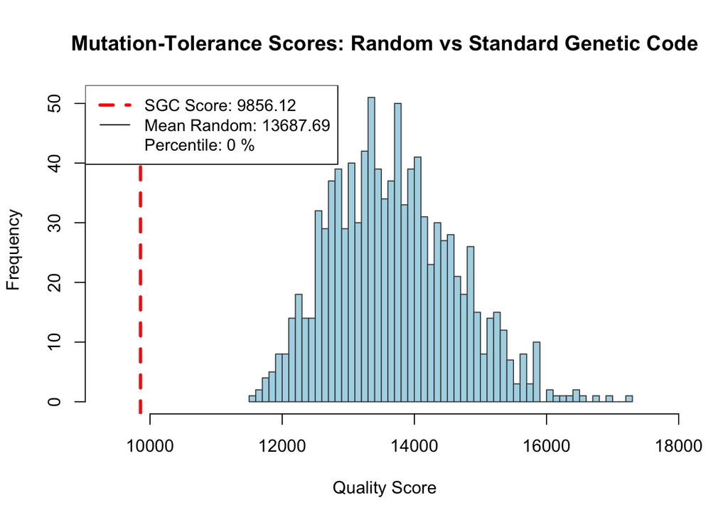

Histogram showing mutation-tolerance scores for 1000 random genetic codes with the Standard Genetic Code score marked in red.

```r
hist(random_scores,
     breaks = 50,
     xlim = c(min(random_scores, sgc_score) - 500, max(random_scores) + 500),
     main = "Mutation-Tolerance Scores: Random vs Standard Genetic Code",
     xlab = "Quality Score",
     ylab = "Frequency",
     col = "lightblue",
     border = "gray30",
     cex.main = 1.2,
     cex.lab = 1.0)

# Add a vertical line marking the SGC score
abline(v = sgc_score, col = "red", lwd = 3, lty = 2)

# Add a legend
legend("topleft",
       legend = c(paste("SGC Score:", round(sgc_score, 2)),
                  paste("Mean Random:", round(mean_random, 2)),
                  paste("Percentile:", round(percentile_sgc, 1), "%")),
       col = c("red", "black", "black"),
       lty = c(2, 1, 0),
       lwd = c(3, 1, 1),
       cex = 0.95)
```

### 3.5 Quantile Analysis

```r
# Quantile comparison
quantiles <- quantile(random_scores, probs = c(0.05, 0.25, 0.5, 0.75, 0.95))

quantile_table <- data.frame(
  Percentile = c("5th", "25th", "50th (Median)", "75th", "95th"),
  Score = round(quantiles, 2),
  SGC_Comparison = c(
    ifelse(sgc_score > quantiles["5%"], "SGC > 5th", "SGC ≤ 5th"),
    ifelse(sgc_score > quantiles["25%"], "SGC > 25th", "SGC ≤ 25th"),
    ifelse(sgc_score > quantiles["50%"], "SGC > median", "SGC ≤ median"),
    ifelse(sgc_score > quantiles["75%"], "SGC > 75th", "SGC ≤ 75th"),
    ifelse(sgc_score > quantiles["95%"], "SGC > 95th", "SGC ≤ 95th")
  )
)

knitr::kable(quantile_table, caption = "Quantile analysis: position of SGC score within the random distribution")
```

Quantile analysis: position of SGC score within the random distribution

|  | Percentile | Score | SGC_Comparison |
| --- | --- | --- | --- |
| 5% | 5th | 12258.80 | SGC ≤ 5th |
| 25% | 25th | 12990.39 | SGC ≤ 25th |
| 50% | 50th (Median) | 13635.07 | SGC ≤ median |
| 75% | 75th | 14315.86 | SGC ≤ 75th |
| 95% | 95th | 15311.71 | SGC ≤ 95th |

## 4 Conclusion

### 4.1 Interpretation

The Standard Genetic Code demonstrates substantially higher mutation tolerance than random alternative codes. The SGC achieved a score of 9856.116, placing it lower than all 1000 randomly generated codes (z = -4.06). This represents a significant deviation from the null expectation that genetic codes are randomly optimized.

### 4.2 Closeness to Global Optimum

However, when analyzing whether the SGC is the best it can possibly be, we can only say that it is likely close, but not at, the global optimum robustness score. This is because this experiment only focused on comparing the SGC to a random distribution of alternative codes, rather than building an algorithm to further optimize below the score 9856.116. Further limitations of this experiment are detailed below.

### 4.3 Limitations and Future Work

**Limitations of this analysis include:**

- **Null model assumptions:** Random codes were generated with uniform probability across all valid assignments. Real alternative codes might reflect different selective pressures (codon usage bias, GC content, translation efficiency) not captured here.
- **Single trait evaluation:** This analysis evaluates only mutation tolerance. The SGC optimizes for multiple traits (translation speed, mRNA stability, tRNA availability, etc.), and optimization for one trait may come at a cost to others (Higgs and Ran 2008).
- **Static snapshot:** The SGC represents a frozen evolutionary optimum. Local search algorithms might identify alternative codes with even higher mutation tolerance, suggesting the SGC occupies a local, not global, optimum.
- **Simplistic codon assignment:** The analysis treats all mutations equally. In reality, mutation rates vary by nucleotide type and genomic context, potentially biasing the effective selective advantage of different code organizations.
- **Stop codon placement:** Requiring only one stop codon allows stop codons to be placed anywhere. In real genomes, stop codons are biased toward specific sequence contexts and their positioning may contribute to code optimization.

### 4.4 Biological Significance

These findings support the hypothesis that the universal genetic code is a product of both historical contingency and adaptive refinement (Wong 1975). The extreme optimization for mutation tolerance suggests that selection for robustness has been a significant evolutionary force, particularly early in the evolution of life when genetic systems were most error-prone (Gilis et al. 2001). This finding has implications for understanding the evolution of genetic systems in other planets or synthetic biology applications where alternative codes might be engineered.

## 5 References

Crick, F. H. 1966. “Codon—anticodon pairing: The wobble hypothesis.” *Journal of Molecular Biology* 19, no. 2: 548–555. https://doi.org/10.1016/S0022-2836(66)80022-0

Freeland, S. J., and L. D. Hurst. 1998. “The genetic code is one in a million.” *Journal of Molecular Evolution* 47, no. 3: 238–248. [https://doi.org/10.1007/pl00006381](https://doi.org/10.1007/PL00006381)

Gilis, D., S. Massar, M. E. Cerf, and M. Rooman. 2001. “Optimality of the genetic code with respect to protein stability and amino-acid frequencies.” *Genome Biology* 2, no. 11: research0049. https://doi.org/10.1186/gb-2001-2-11-research0049

Higgs, P. G., and W. Ran. 2008. “Coevolution of codon usage and tRNA genes leads to alternative stable states of biased codon usage.” *Molecular Biology Evolution* 25, no. 11: 2279-2291. https://doi.org/10.1093/molbev/msn173

Wong, J. T. 1975. “A coevolution theory of the genetic code.” *Proceedings of the National Academy of Sciences* 72, no. 5: 1909–1912. https://doi.org/10.1073/pnas.72.5.1909

## 6 Appendix

### 6.1 Summary of AI Assistance

The Claude Sonnet 4.5 assistant was used for the majority of the development of this analysis, and was able to achieve several tasks listed in the “Strengths” below. Initially, however, the ChatGPT 5 assistant was used, but a major obstacle was faced in setting the proper SGC benchmark that revealed general weaknesses in AI assistance that are listed in the “Weaknesses” below.

**Strengths:**

- Provided a complete, efficient R implementation that correctly computed the benchmark score on first iteration
- Generated well-documented code with clear logic for neighbour generation, score computation, and random code generation
- Implemented appropriate biological constraints (≥1 stop codon) in the random code generator
- Suggested and implemented useful statistical analyses (percentiles, z-scores, quantile comparison)
- Produced visualization code that clearly communicates results

**Weaknesses:**

- Failed to identify critical knowledge gaps about the aaSim() function’s handling of stop codons, instead making unfounded assumptions and proceeding without clarification
- Incorrectly asserted that “aaSim is undefined for Stop” and built flawed logic around this false premise, missing the distinction between literal errors and valid function calls using “*”
- Generated code that executed without errors but produced incorrect results, masking the logical error and creating a false sense of correctness
- Did not recognize or surface its own blind spots regarding the mismatch between its mental model of the function and its actual behavior
- Lacked awareness of standard bioinformatics conventions (e.g., using “*” for stop codons) that would have prevented the fundamental misunderstanding

Ultimately, AI was still able to effectively translated a complex computational protocol into working code and contributed meaningfully to the technical analysis.

## 7 Self-Assessment

**Proposed Mark: 88/100**

**Justification:**

- Report is clear, well-structured, and reproducible. Methods and assumptions are stated, visuals support interpretation, and conclusions are accurate though not overly detailed.
- Cerified the benchmark score (9856.116). Code is correct, readable, and tested, with minor room for better modularity.
- Used AI effectively while making sure to check all results independently.
- Meets “excellent” level—accurate, complete, and thoughtfully executed, though not exceptionally original.